# A&E demand in BNSSG and Gloucestershire: what to plan for in 2027-28

Author

Iyeose Simon

Published

November 2026

**The short version.** Plan for about **500,000 Type 1 (major emergency department) attendances** across the Bristol and Gloucestershire trusts in 2027-28, about 5% more than last year. Gloucestershire’s emergency department runs close to its capacity limit: without extra cover, waits in January 2028 are likely to be noticeably worse.

### 1. Is demand growing?

Yes. Since the pandemic, attendances have grown about **4% a year** in Bristol and **4%** in Gloucestershire, faster in the last year. Winter has fewer arrivals than summer (4% to 7% fewer), but a larger share of them need admitting (about 6% more at both trusts): winter pressure comes from sicker patients, not more of them.

### 2. How much activity should we plan for?

| Area | Plan for 2027-28 | Likely range | Change on last 12 months |
| --- | --- | --- | --- |
| Bristol (Bristol NHS FT) | 325,400 | 318,700 to 332,000 | 5.8% |
| Gloucestershire Hospitals | 174,200 | 167,300 to 181,000 | 4.0% |
| Both trusts | 499,600 | 486,000 to 513,100 | 5.2% |

Likely range: 8 in 10 outcomes. **The risk is mainly upwards for Gloucestershire**: in back-tests, forecasts there came in about 3.5% too low.

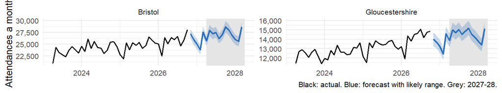

### 3. What does this mean for A&E in January 2028?

Simulating Gloucestershire’s Type 1 department (both sites as one, calibrated to January 2026):

- **With current capacity**, patients leaving A&E within 4 hours fall from about 60% (January 2026) to about **48%** (range 40% to 55%).
- **One extra clinician from 10am to 10pm** adds about **11 percentage points** (range 6 to 15) and cuts the average wait to be seen from 54 to 40 minutes.
- At the top of the demand range, current capacity cannot keep up. Clinician time per patient, the most influential input, is estimated.

### What this means for the 2027-28 plan

1. **Plan on about 500,000 attendances**; stress-test Gloucestershire against the top of its range.
2. **Fund extra clinician cover from 10am to 10pm in winter**, starting with Gloucestershire.
3. **Plan winter beds for sicker patients**: admissions, not arrivals, drive winter pressure.

*Source: NHS England A&E data to October 2026. Type 1 only (below all-types figures). Methods: technical report.*